# California Housing Prices

Median house prices for California districts derived from the 1990 census.

## Description

This is the dataset used in the second chapter of Aurélien Géron's recent book 'Hands-On Machine learning with Scikit-Learn and TensorFlow'. It serves as an excellent introduction to implementing machine learning algorithms because it requires rudimentary data cleaning, has an easily understandable list of variables and sits at an optimal size between being to toyish and too cumbersome.

The data contains information from the 1990 California census. So although it may not help you with predicting current housing prices like the Zillow Zestimate dataset, it does provide an accessible introductory dataset for teaching people about the basics of machine learning.

## Content

The data pertains to the houses found in a given California district and some summary stats about them based on the 1990 census data. Be warned the data aren't cleaned so there are some preprocessing steps required! The columns are as follows, their names are pretty self explanitory:

longitude

latitude

housing_median_age

total_rooms

total_bedrooms

population

households

median_income

median_house_value

ocean_proximity

## Acknowledgements

This data was initially featured in the following paper: Pace, R. Kelley, and Ronald Barry. "Sparse spatial autoregressions." Statistics & Probability Letters 33.3 (1997): 291-297.

and I encountered it in 'Hands-On Machine learning with Scikit-Learn and TensorFlow' by Aurélien Géron. Aurélien Géron wrote: This dataset is a modified version of the California Housing dataset available from: Luís Torgo's page (University of Porto)

# Prepare data

```python
import pandas as pd
import matplotlib.pyplot as plt
import seaborn as sns
```

## Load data

```python
data = pd.read_csv("housing.csv")
```

## Expolore data

```python
data.head()
```

|  | longitude | latitude | housing_median_age | total_rooms | total_bedrooms | population | households | median_income | median_house_value | ocean_proximity |
| --- | --- | --- | --- | --- | --- | --- | --- | --- | --- | --- |
| 0 | -122.23 | 37.88 | 41.0 | 880.0 | 129.0 | 322.0 | 126.0 | 8.3252 | 452600.0 | NEAR BAY |
| 1 | -122.22 | 37.86 | 21.0 | 7099.0 | 1106.0 | 2401.0 | 1138.0 | 8.3014 | 358500.0 | NEAR BAY |
| 2 | -122.24 | 37.85 | 52.0 | 1467.0 | 190.0 | 496.0 | 177.0 | 7.2574 | 352100.0 | NEAR BAY |
| 3 | -122.25 | 37.85 | 52.0 | 1274.0 | 235.0 | 558.0 | 219.0 | 5.6431 | 341300.0 | NEAR BAY |
| 4 | -122.25 | 37.85 | 52.0 | 1627.0 | 280.0 | 565.0 | 259.0 | 3.8462 | 342200.0 | NEAR BAY |

```python
data.info()
```

```
<class 'pandas.core.frame.DataFrame'>
RangeIndex: 20640 entries, 0 to 20639
Data columns (total 10 columns):
longitude             20640 non-null float64
latitude              20640 non-null float64
housing_median_age    20640 non-null float64
total_rooms           20640 non-null float64
total_bedrooms        20433 non-null float64
population            20640 non-null float64
households            20640 non-null float64
median_income         20640 non-null float64
median_house_value    20640 non-null float64
ocean_proximity       20640 non-null object
dtypes: float64(9), object(1)
memory usage: 1.6+ MB
```

```python
data.describe()
```

|  | longitude | latitude | housing_median_age | total_rooms | total_bedrooms | population | households | median_income | median_house_value |
| --- | --- | --- | --- | --- | --- | --- | --- | --- | --- |
| count | 20640.000000 | 20640.000000 | 20640.000000 | 20640.000000 | 20433.000000 | 20640.000000 | 20640.000000 | 20640.000000 | 20640.000000 |
| mean | -119.569704 | 35.631861 | 28.639486 | 2635.763081 | 537.870553 | 1425.476744 | 499.539680 | 3.870671 | 206855.816909 |
| std | 2.003532 | 2.135952 | 12.585558 | 2181.615252 | 421.385070 | 1132.462122 | 382.329753 | 1.899822 | 115395.615874 |
| min | -124.350000 | 32.540000 | 1.000000 | 2.000000 | 1.000000 | 3.000000 | 1.000000 | 0.499900 | 14999.000000 |
| 25% | -121.800000 | 33.930000 | 18.000000 | 1447.750000 | 296.000000 | 787.000000 | 280.000000 | 2.563400 | 119600.000000 |
| 50% | -118.490000 | 34.260000 | 29.000000 | 2127.000000 | 435.000000 | 1166.000000 | 409.000000 | 3.534800 | 179700.000000 |
| 75% | -118.010000 | 37.710000 | 37.000000 | 3148.000000 | 647.000000 | 1725.000000 | 605.000000 | 4.743250 | 264725.000000 |
| max | -114.310000 | 41.950000 | 52.000000 | 39320.000000 | 6445.000000 | 35682.000000 | 6082.000000 | 15.000100 | 500001.000000 |

```
array([[<matplotlib.axes._subplots.AxesSubplot object at 0x10ccba588>,
      dtype=object)
```

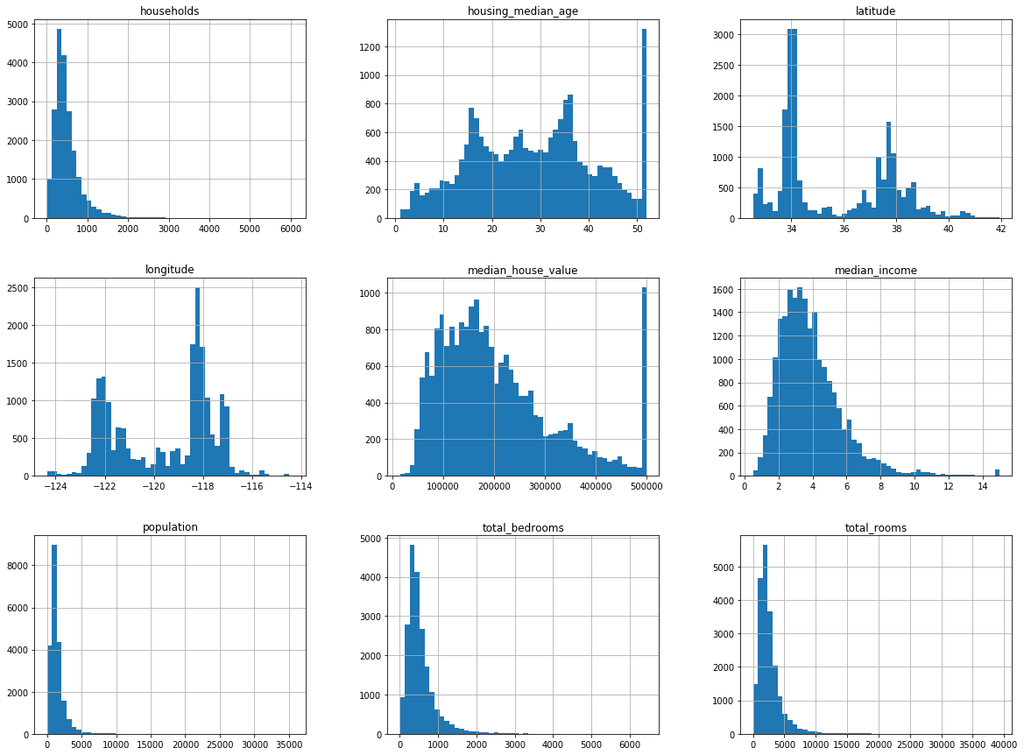

```python
data.hist(bins=50, figsize=(20,15))
```

- The attributes have different scales. It is recommended to rescale all the attributes.
- **The medium house value** has a sudden peak around 500000, which is very different from others. It is recommended to remove these data in training the model.
- **The medium income** is centered around 3, where the unit is unknown. Probably, 3 means $30,000.

**add a new categorical feature in order to split the dataset properly**

This new feature will be deleted afterwards.

```python
data['income_cat'] = np.ceil(data['median_income']/1.5)
data['income_cat'].where(data['income_cat']<5, 5, inplace=True)
```

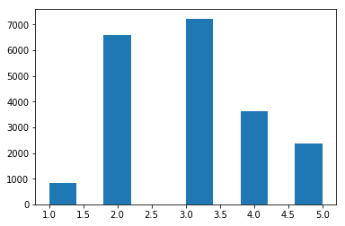

```python
plt.hist(data.income_cat)
```

```python
data.income_cat.value_counts()/len(data.income_cat)
```

```
3.0    0.350581
2.0    0.318847
4.0    0.176308
5.0    0.114438
1.0    0.039826
Name: income_cat, dtype: float64
```

**split the data into train and test sets based on the new feature

Method 1: using the package **train_test_split** without the new feature  
Method 2: using the package **StratifiedShuffleSplit** with the new feature

```python
from sklearn.model_selection import train_test_split
```

```python
data4train,data4test = train_test_split(data, test_size=0.2, random_state=42)
```

```python
from sklearn.model_selection import StratifiedShuffleSplit
split = StratifiedShuffleSplit(n_splits=1, test_size=0.2, random_state = 42)
```

```python
for train_index, test_index in split.split(data, data['income_cat']):
    train_set = data.loc[train_index]
    test_set  = data.loc[test_index]
```

compare the two split methods

```python
def table4income_cat(dataset,df,label):
    df[label]=pd.Series(dataset['income_cat'].value_counts()/len(dataset['income_cat']))
    return df
```

```python
df = pd.DataFrame()
df = table4income_cat(train_set,df,'All_set')
df = table4income_cat(train_set,df,'train_set_Shuff')
df = table4income_cat(test_set,df,'test_set_Shuff')
df = table4income_cat(data4train,df,'train_set_split')
df = table4income_cat(data4test,df,'test_set_split')
df
```

|  | All_set | train_set_Shuff | test_set_Shuff | train_set_split | test_set_split |
| --- | --- | --- | --- | --- | --- |
| 3.0 | 0.350594 | 0.350594 | 0.350533 | 0.348595 | 0.358527 |
| 2.0 | 0.318859 | 0.318859 | 0.318798 | 0.317466 | 0.324370 |
| 4.0 | 0.176296 | 0.176296 | 0.176357 | 0.178537 | 0.167393 |
| 5.0 | 0.114402 | 0.114402 | 0.114583 | 0.115673 | 0.109496 |
| 1.0 | 0.039850 | 0.039850 | 0.039729 | 0.039729 | 0.040213 |

It is shown above that the **StratifiedShuffleSplit** method works a little bit better as the income category propotions in train data and test data are closer to that in the all dataset.

After split the data into train and test, we delete the newly added feature.

```python
# delete the new feature
for set_ in (data, data4train, data4test, train_set, test_set):
    set_.drop("income_cat",axis=1,inplace=True)
```

```python
data4train.columns
```

```
Index(['longitude', 'latitude', 'housing_median_age', 'total_rooms',
       'total_bedrooms', 'population', 'households', 'median_income',
       'median_house_value', 'ocean_proximity'],
      dtype='object')
```

```python
housing4train = train_set.copy()
```

```python
housing4train.head()
```

|  | longitude | latitude | housing_median_age | total_rooms | total_bedrooms | population | households | median_income | median_house_value | ocean_proximity |
| --- | --- | --- | --- | --- | --- | --- | --- | --- | --- | --- |
| 17606 | -121.89 | 37.29 | 38.0 | 1568.0 | 351.0 | 710.0 | 339.0 | 2.7042 | 286600.0 | <1H OCEAN |
| 18632 | -121.93 | 37.05 | 14.0 | 679.0 | 108.0 | 306.0 | 113.0 | 6.4214 | 340600.0 | <1H OCEAN |
| 14650 | -117.20 | 32.77 | 31.0 | 1952.0 | 471.0 | 936.0 | 462.0 | 2.8621 | 196900.0 | NEAR OCEAN |
| 3230 | -119.61 | 36.31 | 25.0 | 1847.0 | 371.0 | 1460.0 | 353.0 | 1.8839 | 46300.0 | INLAND |
| 3555 | -118.59 | 34.23 | 17.0 | 6592.0 | 1525.0 | 4459.0 | 1463.0 | 3.0347 | 254500.0 | <1H OCEAN |

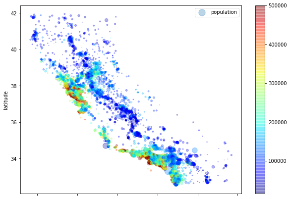

```python
housing4train.plot(kind='scatter', x='longitude', y='latitude', alpha=0.3,
         s=housing4train['population']/100, label='population',   # set symbol size on population
         c=housing4train['median_house_value'],                  #  set symbol color on house value
         cmap=plt.get_cmap('jet'),
         colorbar=True,
         figsize=(10,7))
plt.legend()
```

- The **house value** depends much on the *population* and *location*.

```python
import folium

from geopy.geocoders import Nominatim
```

```python
def get_latlon(address):
    geolocator = Nominatim()
    location   = geolocator.geocode(address)
    latitude   = location.latitude
    longitude  = location.longitude
    return latitude, longitude
```

```python
# latitude, longitude = get_latlon("1070 E Arques Ave, Sunnyvale, CA")

# California_map = folium.Map(location=[latitude, longitude], zoom_start=12)
# for lat, lng, house_value, population in zip(data['latitude'], data['longitude'], data['median_house_value'],
#                                          data['population']):
#     labels = 'House_Value:{}, Population: {}'.format(house_value,population)
#     label = folium.Popup(labels,parse_html=True)
#     folium.CircleMarker(
#         [lat, lng],
#         radius=5,
#         color='blue',
#         popup=label,
#         fill=True,
#         #fill_color='#3186cc',
#         fill_opacity=0.7,
#         parse_html=False).add_to(California_map)

# California_map
```

**Check the correlations between pairs of features**

**analysis correlations**

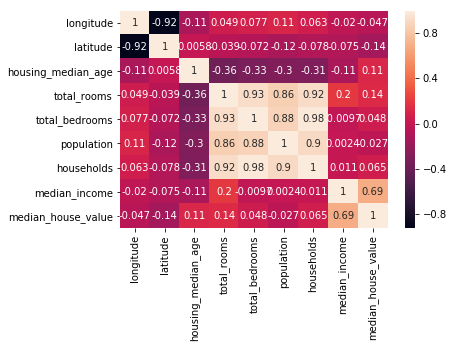

```python
sns.heatmap(housing4train.corr(),annot=True)
```

```python
corr_matrix = housing4train.corr()
corr_matrix['median_house_value'].sort_values(ascending=False)
```

```
median_house_value    1.000000
median_income         0.687160
total_rooms           0.135097
housing_median_age    0.114110
households            0.064506
total_bedrooms        0.047689
population           -0.026920
longitude            -0.047432
latitude             -0.142724
Name: median_house_value, dtype: float64
```

```python
corr_matrix
```

|  | longitude | latitude | housing_median_age | total_rooms | total_bedrooms | population | households | median_income | median_house_value |
| --- | --- | --- | --- | --- | --- | --- | --- | --- | --- |
| longitude | 1.000000 | -0.924478 | -0.105848 | 0.048871 | 0.076598 | 0.108030 | 0.063070 | -0.019583 | -0.047432 |
| latitude | -0.924478 | 1.000000 | 0.005766 | -0.039184 | -0.072419 | -0.115222 | -0.077647 | -0.075205 | -0.142724 |
| housing_median_age | -0.105848 | 0.005766 | 1.000000 | -0.364509 | -0.325047 | -0.298710 | -0.306428 | -0.111360 | 0.114110 |
| total_rooms | 0.048871 | -0.039184 | -0.364509 | 1.000000 | 0.929379 | 0.855109 | 0.918392 | 0.200087 | 0.135097 |
| total_bedrooms | 0.076598 | -0.072419 | -0.325047 | 0.929379 | 1.000000 | 0.876320 | 0.980170 | -0.009740 | 0.047689 |
| population | 0.108030 | -0.115222 | -0.298710 | 0.855109 | 0.876320 | 1.000000 | 0.904637 | 0.002380 | -0.026920 |
| households | 0.063070 | -0.077647 | -0.306428 | 0.918392 | 0.980170 | 0.904637 | 1.000000 | 0.010781 | 0.064506 |
| median_income | -0.019583 | -0.075205 | -0.111360 | 0.200087 | -0.009740 | 0.002380 | 0.010781 | 1.000000 | 0.687160 |
| median_house_value | -0.047432 | -0.142724 | 0.114110 | 0.135097 | 0.047689 | -0.026920 | 0.064506 | 0.687160 | 1.000000 |

```python
df = corr_matrix.tail(1).T
df
```

|  | median_house_value |
| --- | --- |
| longitude | -0.047432 |
| latitude | -0.142724 |
| housing_median_age | 0.114110 |
| total_rooms | 0.135097 |
| total_bedrooms | 0.047689 |
| population | -0.026920 |
| households | 0.064506 |
| median_income | 0.687160 |
| median_house_value | 1.000000 |

```python
df.sort_values(by='median_house_value',inplace=True)
df
```

|  | median_house_value |
| --- | --- |
| latitude | -0.142724 |
| longitude | -0.047432 |
| population | -0.026920 |
| total_bedrooms | 0.047689 |
| households | 0.064506 |
| housing_median_age | 0.114110 |
| total_rooms | 0.135097 |
| median_income | 0.687160 |
| median_house_value | 1.000000 |

```python
features = list(df[abs(df['median_house_value'])>0.1].T.columns)
features
```

```
['latitude',
 'housing_median_age',
 'total_rooms',
 'median_income',
 'median_house_value']
```

```python
from pandas.plotting import scatter_matrix
```

```python
#scatter_matrix(data[features],figsize=(12,8))
```

**Iteractive plot**

```python
from plotly.graph_objs import Scatter,Layout
import plotly
import plotly.offline as py
import plotly.graph_objs as go
```

```python
plotly.offline.init_notebook_mode(connected=True)
```

```python
trace0 = go.Scatter(x=data['median_income'], y=data['median_house_value'], mode = 'markers', name = 'value vs income')
```

```python
#py.iplot([trace0])
```

## Attribute combination

The **total rooms** in a particular district is not much related to the house price if the population is not specified. The more relevant variable for the house price is the number of people in a house. Therefore, one may introduce a new attribute **population_per_household**.

```python
housing4train['population_per_household'] = housing4train['population']/housing4train['households']
```

In addition, the number of rooms per household and bedrooms per rooms are introduced.

```python
housing4train['bedrooms_per_room'] = housing4train['total_bedrooms']/housing4train['total_rooms']
housing4train['rooms_per_household'] = housing4train['total_rooms']/housing4train['households']
```

```python
corr_matrix = housing4train.corr()
```

```python
df = pd.DataFrame(corr_matrix['median_house_value'])
df.sort_values(by='median_house_value',inplace=True)
```

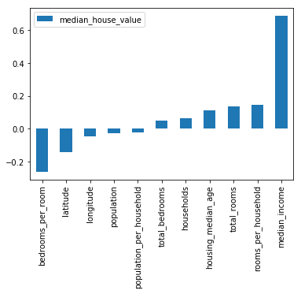

```python
df.drop(index='median_house_value',inplace=True)
df.plot(kind='bar')
```

```python
features = list(df[abs(df['median_house_value'])>0.15].T.columns)
features
```

```
['bedrooms_per_room', 'median_income']
```

## Prepare Data for Machine Learning Algorithm

```python
X_train = data4train.drop("median_house_value",axis=1)
y_train = data4train["median_house_value"].copy()
```

```python
X_train.shape,y_train.shape
```

```
((16512, 9), (16512,))
```

```python
X_test = data4test.drop("median_house_value",axis=1)
y_test = data4test["median_house_value"].copy()
```

### missing data?

```python
#missing data
def report_missing_data(dataset):
    total = dataset.isnull().sum().sort_values(ascending=False)
    percent = dataset.isnull().sum()/total

    missing_data = pd.concat([total, percent], axis=1, keys=['Total', 'Percent'])
    missing_data.plot(kind='bar',y='Total',figsize=(10,6),fontsize=20)
    print(missing_data)
```

[output not shown]

[figure not shown]

```python
report_missing_data(X_test)
```

[output not shown]

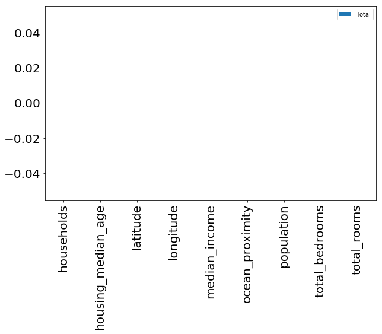

```python
report_missing_data(X_train)
```

```python
X_train = train_set.drop("median_house_value",axis=1)
y_train = train_set["median_house_value"].copy()

X_test = test_set.drop("median_house_value",axis=1)
y_test = test_set["median_house_value"].copy()
```

```
                    Total  Percent
households              0      NaN
housing_median_age      0      NaN
latitude                0      NaN
longitude               0      NaN
median_income           0      NaN
ocean_proximity         0      NaN
population              0      NaN
total_bedrooms        158      1.0
total_rooms             0      NaN
```

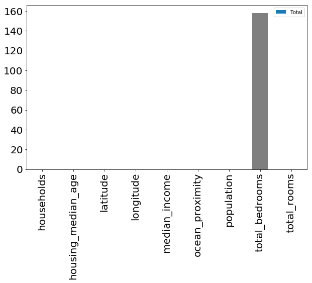

```python
report_missing_data(X_train)
```

### Clean the data

Three ways to take care of the missing value/"NaN":

- data.dropna(subset=["total_bedrooms"])
- data.drop("total_bedrooms",axis=1)
- data["total_bedrooms"].fillna(median,inplace=True), where median = data["total_bedrooms"].median()

```python
X_train['total_bedrooms'].isnull().sum()
```

```
158
```

```python
missing_feature = pd.DataFrame(X_train.isnull().sum().sort_values(ascending=False)).index[0]
missing_feature
```

```
'total_bedrooms'
```

**Only the total bedrooms** contains missing values.

```python
median=X_train[missing_feature].median()
X_train[missing_feature]=X_train[missing_feature].replace(np.nan,median)
X_train[missing_feature].isnull().sum()
```

```
0
```

```python
median=X_test[missing_feature].median()
X_test[missing_feature]=X_test[missing_feature].replace(np.nan,median)
X_test[missing_feature].isnull().sum()
```

```
0
```

### Categorical data with one-hot encoding

```python
X_train['ocean_proximity'].unique()
```

```
array(['<1H OCEAN', 'NEAR OCEAN', 'INLAND', 'NEAR BAY', 'ISLAND'],
      dtype=object)
```

```python
housing_num = X_train.drop("ocean_proximity",axis=1)
num_attribs = list(housing_num)
```

```python
num_attribs
```

```
['longitude',
 'latitude',
 'housing_median_age',
 'total_rooms',
 'total_bedrooms',
 'population',
 'households',
 'median_income']
```

```python
from sklearn.pipeline import Pipeline
from sklearn.preprocessing import StandardScaler,RobustScaler
from sklearn.preprocessing import Imputer
from sklearn.pipeline import FeatureUnion
#CategoricalEncoder(encoding='onehot-dense')


from sklearn.base import BaseEstimator,TransformerMixin
#select columns and transit to array

from sklearn.base import BaseEstimator, TransformerMixin
from sklearn.utils import check_array
from sklearn.preprocessing import LabelEncoder
from scipy import sparse

class CategoricalEncoder(BaseEstimator, TransformerMixin):


    def __init__(self, encoding='onehot', categories='auto', dtype=np.float64,
                 handle_unknown='error'):
        self.encoding = encoding
        self.categories = categories
        self.dtype = dtype
        self.handle_unknown = handle_unknown

    def fit(self, X, y=None):

        if self.encoding not in ['onehot', 'onehot-dense', 'ordinal']:
            template = ("encoding should be either 'onehot', 'onehot-dense' "
                        "or 'ordinal', got %s")
            raise ValueError(template % self.handle_unknown)

        if self.handle_unknown not in ['error', 'ignore']:
            template = ("handle_unknown should be either 'error' or "
                        "'ignore', got %s")
            raise ValueError(template % self.handle_unknown)

        if self.encoding == 'ordinal' and self.handle_unknown == 'ignore':
            raise ValueError("handle_unknown='ignore' is not supported for"
                             " encoding='ordinal'")

        X = check_array(X, dtype=np.object, accept_sparse='csc', copy=True)
        n_samples, n_features = X.shape

        self._label_encoders_ = [LabelEncoder() for _ in range(n_features)]

        for i in range(n_features):
            le = self._label_encoders_[i]
            Xi = X[:, i]
            if self.categories == 'auto':
                le.fit(Xi)
            else:
                valid_mask = np.in1d(Xi, self.categories[i])
                if not np.all(valid_mask):
                    if self.handle_unknown == 'error':
                        diff = np.unique(Xi[~valid_mask])
                        msg = ("Found unknown categories {0} in column {1}"
                               " during fit".format(diff, i))
                        raise ValueError(msg)
                le.classes_ = np.array(np.sort(self.categories[i]))

        self.categories_ = [le.classes_ for le in self._label_encoders_]

        return self

    def transform(self, X):
        X = check_array(X, accept_sparse='csc', dtype=np.object, copy=True)
        n_samples, n_features = X.shape
        X_int = np.zeros_like(X, dtype=np.int)
        X_mask = np.ones_like(X, dtype=np.bool)

        for i in range(n_features):
            valid_mask = np.in1d(X[:, i], self.categories_[i])

            if not np.all(valid_mask):
                if self.handle_unknown == 'error':
                    diff = np.unique(X[~valid_mask, i])
                    msg = ("Found unknown categories {0} in column {1}"
                           " during transform".format(diff, i))
                    raise ValueError(msg)
                else:
                    X_mask[:, i] = valid_mask
                    X[:, i][~valid_mask] = self.categories_[i][0]
            X_int[:, i] = self._label_encoders_[i].transform(X[:, i])

        if self.encoding == 'ordinal':
            return X_int.astype(self.dtype, copy=False)

        mask = X_mask.ravel()
        n_values = [cats.shape[0] for cats in self.categories_]
        n_values = np.array([0] + n_values)
        indices = np.cumsum(n_values)

        column_indices = (X_int + indices[:-1]).ravel()[mask]
        row_indices = np.repeat(np.arange(n_samples, dtype=np.int32),
                                n_features)[mask]
        data = np.ones(n_samples * n_features)[mask]

        out = sparse.csc_matrix((data, (row_indices, column_indices)),
                                shape=(n_samples, indices[-1]),
                                dtype=self.dtype).tocsr()
        if self.encoding == 'onehot-dense':
            return out.toarray()
        else:
            return out

class DataFrameSelector(BaseEstimator,TransformerMixin):
    def __init__(self,feature_names):
        self.feature_names = feature_names
    def fit(self,X,y=None):
        return self
    def transform(self,X):
        return X[self.feature_names].values


# build pipelines
cat_attribs = ['ocean_proximity']
num_attribs = list(housing_num)

num_pipeline = Pipeline([
               ('selector',DataFrameSelector(num_attribs)),
               ('std_scaler',StandardScaler()),
                ])

# build categorical pipeline
cat_pipeline = Pipeline([
                  ('selector',DataFrameSelector(cat_attribs)),
                  ('cat_encoder',CategoricalEncoder(encoding='onehot-dense')),
              ])


# concatenate all the transforms using "FeatureUnion"
pipelines = FeatureUnion(transformer_list=
                             [
                              ('num_pipeline',num_pipeline),
                              ('cat_pipeline',cat_pipeline),
                             ])
```

```python
X_train_prepared = pipelines.fit_transform(X_train)
```

```python
X_train_prepared.shape
```

```
(16512, 13)
```

```python
type(X_train_prepared)
```

```
numpy.ndarray
```

# Select and train a model

```python
from sklearn.metrics import mean_absolute_error,mean_squared_error

def model_performace(model,X,y):
    model.fit(X,y)
    pred = model.predict(X)
    scores = np.sqrt(mean_squared_error(pred,y))

    print("scores:",scores)
    print("Mean:",scores.mean())
    print("Standard Deviation:",scores.std())
    return model,pred
```

```python
def plot_pred_true(ypred,ytrue):
    df = pd.DataFrame([ypred,ytrue]).T
    df.columns=['pred','true']
    plt.scatter(df['pred'],df['true'])
```

## Linear regression (prone to under fit the data)

```python
from sklearn.linear_model import LinearRegression
```

```python
lr = LinearRegression()
lr_model,ypred = model_performace(lr,X_train_prepared, y_train)
```

```
scores: 69050.98178244587
Mean: 69050.98178244587
Standard Deviation: 0.0
```

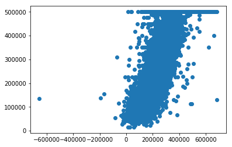

```python
plot_pred_true(ypred,y_train)
```

## Support Vector Machine

```python
from sklearn import svm
```

```python
clf  = svm.SVR(kernel='poly',degree=3)
svr_model,ypred = model_performace(clf,X_train_prepared,y_train)
```

```
scores: 118640.88533698737
Mean: 118640.88533698737
Standard Deviation: 0.0
```

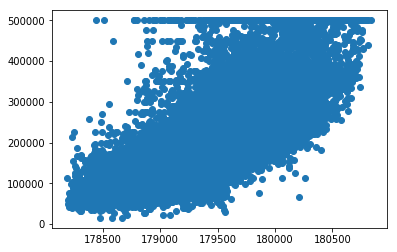

```python
plot_pred_true(ypred,y_train)
```

```python
# svm_rmse = 1
# for C in range(2000,100000,20000):
#     for gamma in np.logspace(-8, -6, 3):
#         clf = svm.SVR(kernel='rbf', degree=3, C=C, gamma=gamma).fit(X_train_prepared,y_train)
#         #y_test_pred = clf.predict(X_test)
#         #rmse = np.sqrt(mean_squared_error(y_test_pred,y_test))
#         y_pred = clf.predict(X_train_prepared)
#         rmse = np.sqrt(mean_squared_error(y_pred,y_train))
#         print("C:{}, gamma:{} rmse:{}".format(C,gamma, rmse))

#         if(svm_rmse > rmse):
#             svm_best = clf
#             svm_rmse = rmse

# print("The best score with rmse={}".format(svm_rmse))
```

[output not shown]

[output not shown]

## Decision Tree (prone to overfit the data)

```python
from sklearn.tree import DecisionTreeRegressor
```

```python
tree = DecisionTreeRegressor()
tree_model,ypred= model_performace(tree,X_train_prepared, y_train)
```

```
scores: 0.0
Mean: 0.0
Standard Deviation: 0.0
```

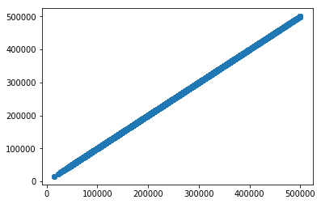

```python
plot_pred_true(ypred,y_train)
```

## Cross-Validation

```python
from sklearn.model_selection import cross_val_score
```

```python
scores = cross_val_score(tree,X_train_prepared,y_train, scoring="neg_mean_squared_error",cv=10)
```

```python
tree_rmse_score=np.sqrt(-scores)
```

```python
def display_scores(scores):
    print("scores:",scores)
    print("Mean:",scores.mean())
    print("Standard Deviation:",scores.std())
```

```python
display_scores(tree_rmse_score)
```

```
scores: [66855.08817709 65281.38390775 72588.16228709 69803.9966613
 65897.83253408 76413.5136803  67201.27627995 70327.10820383
 68426.17405539 67685.95748111]
Mean: 69048.04932678945
Standard Deviation: 3218.1239792468496
```

## Random Forest

```python
from sklearn.ensemble import RandomForestRegressor
```

```python
forest = RandomForestRegressor()
forest_model,y_pred = model_performace(forest,X_train_prepared,y_train)
```

```
scores: 22100.794740299967
Mean: 22100.794740299967
Standard Deviation: 0.0
```

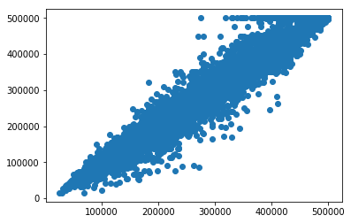

```python
plot_pred_true(y_pred,y_train)
```

# Test dataset

Transform the test data in the same way

```python
X_test_prepared = pipelines.transform(X_test)
```

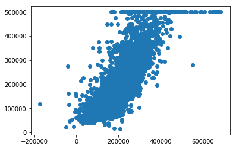

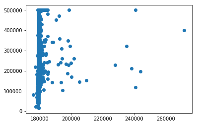

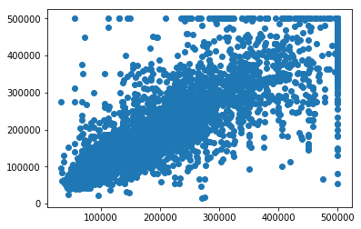

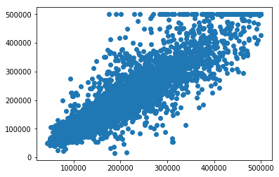

```python
models = [lr_model,svr_model,tree_model,forest_model]

for model in models:
    test_pred = model.predict(X_test_prepared)
    plot_pred_true(test_pred,y_test)
    plt.show()
```

# Save model

```python
from sklearn.externals import joblib
```

```python
# joblib.dump(model, "my_model.pkl")

# my_model_load = joblib.load("my_model.pkl")
```